# Joy of Tech - Python Coding

[figure not shown]

Ed Schofield

```python
print('Hello, Girls in Tech! \U0001f4e3')
```

## Who am I?

- Dr Edward Schofield (or just "Ed")
- Founder and CEO of Python Charmers: https://pythoncharmers.com
- Based in Melbourne, Australia.

We work with Girls in Tech delivering the CODE G bootcamps and Global Classroom program.

We teach short courses worldwide in Python and Data Science.

[figure not shown]

## Goal

You can find plenty of other resources to show that coding skills are "important".

Here we'll focus on what's possible -- and what's fun.

## Structure

- 10 live demos of ~3.5 mins each

What could possible go wrong? 😀

## Demo #1: emoji

```python
from emoji import emojize, demojize
```

```python
emojize(':megaphone:')
```

[output not shown]

```python
demojize('📣')
```

[output not shown]

```python
demojize('♻️')
```

[output not shown]

```python
emojize(':broccoli:')
```

[output not shown]

```python
emojize(':drum: :dragon: :sparkles:')
```

[output not shown]

```python
icecream = emojize(':soft_ice_cream:')
filename = icecream + '.txt'
```

```python
from pathlib import Path

Path(filename).write_text(icecream * 100);
```

```python
!ls *.txt
```

```
requirements.txt 🍦.txt
```

[figure not shown]

### Where are you from?

Type it in the chat!

e.g. "Reykjavik, Iceland"

```python
cities = '''
Melbourne, Australia
San Francisco, United States
Lagos, Nigeria
Singapore, Singapore
Reykjavik, Iceland
Kyoto, Japan
Lyon, France
Hong Kong, China
'''
```

```python
# More ...
cities += '''
Wellington, New Zealand
Cairo, Egypt
Santiago, Chile
Istanbul, Turkey
London, United Kingdom
New York, United States
Seattle, United States
'''
```

```python
import pandas as pd
from io import StringIO

places = pd.read_csv(StringIO(cities),
                     names=['City', 'Country'],
                     skipinitialspace=True)

places
```

|  | City | Country |
| --- | --- | --- |
| 0 | Melbourne | Australia |
| 1 | San Francisco | United States |
| 2 | Lagos | Nigeria |
| 3 | Singapore | Singapore |
| 4 | Reykjavik | Iceland |
| 5 | Kyoto | Japan |
| 6 | Lyon | France |
| 7 | Hong Kong | China |
| 8 | Wellington | New Zealand |
| 9 | Cairo | Egypt |
| 10 | Santiago | Chile |
| 11 | Istanbul | Turkey |
| 12 | London | United Kingdom |
| 13 | New York | United States |
| 14 | Seattle | United States |

### Emoji flags

```python
emojize(':Iceland:')
```

```
'🇮🇸'
```

```python
def get_flag(country):
    return emojize(f':{country}:')
```

```python
places['Flag'] = places['Country'].str.replace(' ', '_').apply(get_flag)
```

```python
places
```

|  | City | Country | Flag |
| --- | --- | --- | --- |
| 0 | Melbourne | Australia | 🇦🇺 |
| 1 | San Francisco | United States | 🇺🇸 |
| 2 | Lagos | Nigeria | 🇳🇬 |
| 3 | Singapore | Singapore | 🇸🇬 |
| 4 | Reykjavik | Iceland | 🇮🇸 |
| 5 | Kyoto | Japan | 🇯🇵 |
| 6 | Lyon | France | 🇫🇷 |
| 7 | Hong Kong | China | 🇨🇳 |
| 8 | Wellington | New Zealand | 🇳🇿 |
| 9 | Cairo | Egypt | 🇪🇬 |
| 10 | Santiago | Chile | 🇨🇱 |
| 11 | Istanbul | Turkey | 🇹🇷 |
| 12 | London | United Kingdom | 🇬🇧 |
| 13 | New York | United States | 🇺🇸 |
| 14 | Seattle | United States | 🇺🇸 |

```python
places.to_excel('places.xlsx', index=False)
```

## Demo #2: Sending a text message

There are API services for messaging like Twilio.

```python
message = emojize('Hello :sparkles:!')
message
```

```
'Hello ✨!'
```

```python
from messaging import sms

sms('+61405676229', message)
```

[figure not shown]

… or many messages.

Use case: Customer notifications (Uber, Amazon, Apple, DHL, ...)

### Loops: computers 🧡 repetition

```python
from time import sleep

for i in range(5):
    print(message)
    sleep(1)
```

```
Hello ✨!
Hello ✨!
Hello ✨!
Hello ✨!
Hello ✨!
```

```python
from tqdm import tqdm as progress

print('Sending 1 million notifications ...', flush=True)
for i in progress(range(10**6)):
    sleep(10**-6)
```

```
Sending 1 million notifications ...
```

## Demo #3: Fetching images via an API

[figure not shown]

```python
import requests

dog_breeds_url = 'https://dog.ceo/api/breeds/list/all'
response = requests.get(dog_breeds_url)
breeds = response.json()['message']

list(breeds)[:10]
```

```
['affenpinscher',
 'african',
 'airedale',
 'akita',
 'appenzeller',
 'australian',
 'basenji',
 'beagle',
 'bluetick',
 'borzoi']
```

Wrapping code in a function lets you call it at will.

```python
import random
from IPython.display import Image

def get_dog(breed):
    dog_url = f'https://dog.ceo/api/breed/{breed}/images'
    response = requests.get(dog_url)
    photo_urls = response.json()['message']
    photo_url = random.choice(photo_urls)
    response = requests.get(photo_url)
    return Image(response.content)
```

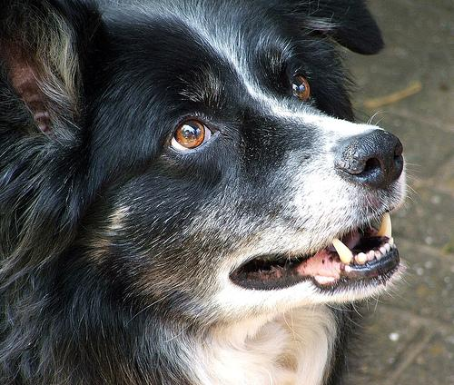

```python
dog = get_dog('collie')
dog
```

## Demo #4: Gluing together different services

What's next? We can use Python to glue together many different web services. This shows sending a photo to a phone via MMS:

```python
from messaging import mms

mms('+61405676229', dog)
```

[figure not shown]

Now we can add an interface allowing user selection:

```python
from ipywidgets import interact

interact(get_dog, breed=list(breeds));
```

[figure not shown]

We'll come back to more kinds of interactivity later.

### Wikipedia

There's a Python package for almost everything ...

```python
import wikipedia

page = wikipedia.page('Girls in Tech')
page.content[:200]
```

```
'Girls in Tech is a global non-profit organization focused on the engagement, education, and empowerment of women in technology. Founded in 2007 by Adriana Gascoigne, the organization has grown from Sa'
```

### Word clouds

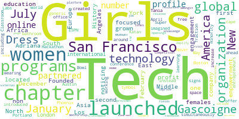

```python
import wordcloud

c = wordcloud.WordCloud(background_color='white')

c.generate(page.content).to_image()
```

### Code re-use

We can link these two with another custom function:

```python
def wikicloud(search_term):
    page = wikipedia.page(search_term, auto_suggest=False)
    c = wordcloud.WordCloud(background_color='white')
    return c.generate(page.content).to_image()
```

Now a custom "Wikicloud" is just a function call away ...

## Demo #5: Interactivity

```python
from ipywidgets import interact_manual

interact_manual(wikicloud, search_term='Girls in Tech');
```

[figure not shown]

### City photos

```python
page = wikipedia.page(title='London')

photos = [url for url in page.images if url.endswith('.jpg')]
```

```python
show_image = lambda url: Image(url)

interact(show_image, url=photos);
```

[figure not shown]

## Demo #6: Real-time services: weather right now

These days there are over a million APIs available.

Here I'll use one called OpenWeatherMap for fetching weather data from anywhere on Earth.

```python
from tools import weather_url, weather_api_key

weather_url
```

```
'https://api.openweathermap.org/data/2.5/weather'
```

```python
def get_weather(city):
    params = {'q': city, 'appid': weather_api_key, 'units': 'metric'}
    response = requests.get(weather_url, params)
    if response.status_code != 200:
        return None
    weather = response.json()
    return weather
```

```python
from pprint import pprint    # pretty print

pprint(get_weather('Reykjavik,IS'))
```

```
{'base': 'stations',
 'clouds': {'all': 90},
 'cod': 200,
 'coord': {'lat': 64.14, 'lon': -21.9},
 'dt': 1599699517,
 'id': 3413829,
 'main': {'feels_like': 3.72,
          'humidity': 81,
          'pressure': 1001,
          'temp': 9,
          'temp_max': 9,
          'temp_min': 9},
 'name': 'Reykjavik',
 'sys': {'country': 'IS',
         'id': 91,
         'sunrise': 1599719846,
         'sunset': 1599768708,
         'type': 1},
 'timezone': 0,
 'visibility': 10000,
 'weather': [{'description': 'overcast clouds',
              'icon': '04n',
              'id': 804,
              'main': 'Clouds'}],
 'wind': {'deg': 160, 'speed': 6.2}}
```

### Temperatures

```python
from tools import get_temperature

get_temperature('Reykjavik,IS')
```

```
9
```

### Weather icons

The API provides URLs of little icons representing the weather.

[figure not shown]

Here's how we can display these.

```python
def get_icon_url(icon_code, size=2):
    return f'http://openweathermap.org/img/wn/{icon_code}@{size}x.png'

def get_icon(icon_code, size=2):
    return Image(get_icon_url(icon_code, size))
```

```python
def weather_icon(city, size=2):
    weather = get_weather(city)
    icon_code = weather['weather'][0]['icon']
    return get_icon(icon_code, size=size)

weather_icon('Seattle,US')
```

Can we apply this function to every row? Not yet: the API requires ISO country codes to disambiguate city names from different countries.

This loads a countries dataset from another file:

```python
all_countries = pd.read_hdf('countries.h5')

all_countries[:8]
```

| Country | Country Code | Capital |
| --- | --- | --- |
| Afghanistan | AF | Kabul |
| Albania | AL | Tirana |
| Algeria | DZ | Algiers |
| Andorra | AD | Andorra la Vella |
| Angola | AO | Luanda |
| Antigua and Barbuda | AG | St. John's |
| Azerbaijan | AZ | Baku |
| Argentina | AR | Buenos Aires |

### Joining datasets

This code (using the *Pandas* package) performs a database-style "join" operation to fetch the country code for all the participants' locations.

```python
places = places.set_index(
    'Country'
).join(
    all_countries['Country Code']
).reset_index()

places[:8]
```

|  | Country | City | Flag | Country Code |
| --- | --- | --- | --- | --- |
| 0 | Australia | Melbourne | 🇦🇺 | AU |
| 1 | Chile | Santiago | 🇨🇱 | CL |
| 2 | China | Hong Kong | 🇨🇳 | CN |
| 3 | Egypt | Cairo | 🇪🇬 | EG |
| 4 | France | Lyon | 🇫🇷 | FR |
| 5 | Iceland | Reykjavik | 🇮🇸 | IS |
| 6 | Japan | Kyoto | 🇯🇵 | JP |
| 7 | New Zealand | Wellington | 🇳🇿 | NZ |

### Applying the `get_temperature` function to every row

```python
places['Location'] = places['City'] + ',' + places['Country Code']

places['Temperature'] = places['Location'].apply(get_temperature)

places
```

|  | Country | City | Flag | Country Code | Location | Temperature |
| --- | --- | --- | --- | --- | --- | --- |
| 0 | Australia | Melbourne | 🇦🇺 | AU | Melbourne,AU | 14.42 |
| 1 | Chile | Santiago | 🇨🇱 | CL | Santiago,CL | 15.76 |
| 2 | China | Hong Kong | 🇨🇳 | CN | Hong Kong,CN | 26.81 |
| 3 | Egypt | Cairo | 🇪🇬 | EG | Cairo,EG | 26.00 |
| 4 | France | Lyon | 🇫🇷 | FR | Lyon,FR | 16.82 |
| 5 | Iceland | Reykjavik | 🇮🇸 | IS | Reykjavik,IS | 9.00 |
| 6 | Japan | Kyoto | 🇯🇵 | JP | Kyoto,JP | 25.90 |
| 7 | New Zealand | Wellington | 🇳🇿 | NZ | Wellington,NZ | 13.44 |
| 8 | Nigeria | Lagos | 🇳🇬 | NG | Lagos,NG | 22.77 |
| 9 | Singapore | Singapore | 🇸🇬 | SG | Singapore,SG | 27.21 |
| 10 | Turkey | Istanbul | 🇹🇷 | TR | Istanbul,TR | 21.05 |
| 11 | United Kingdom | London | 🇬🇧 | GB | London,GB | 13.82 |
| 12 | United States | San Francisco | 🇺🇸 | US | San Francisco,US | 15.35 |
| 13 | United States | New York | 🇺🇸 | US | New York,US | 24.20 |
| 14 | United States | Seattle | 🇺🇸 | US | Seattle,US | 29.19 |

### Spreadsheet output

```python
places.to_excel('temperatures.xlsx', index=False)
```

## Demo #7: biofuel-powered cars

[figure not shown]

If we powered all the cars on a road using biofuels grown on the verge of the road, how wide would the verge have to be?

This is Sir David Mackay's biofuels example from here:

http://www.inference.eng.cam.ac.uk/sustainable/blog/PoweringTransport.html

[figure not shown]

#### Assumptions

- one lane of cars travelling 60 miles per hour
- average car fuel consumption: 30 miles per imperial gallon
- 80 metres spacing between cars
- 1200 litres of biofuel grown per hectare per year

```python
from pint import UnitRegistry

u = UnitRegistry()
```

```python
speed = 60 * u.mile / u.hour
fuel_consumption = 30 * u.mile / u.imperial_gallon
car_spacing = 80 * u.meter
biofuel_productivity = 1200 * u.liter / u.hectare / u.year
```

#### Quick answer: speed divided by the other three terms

```python
verge_width = speed / (fuel_consumption * biofuel_productivity * car_spacing)
round(verge_width.to('miles'), 1)
```

5.2 mile

```python
round(verge_width.to('km'), 1)
```

8.3 kilometer

Hmmm ...

See David Mackay's TED talk for more on the implications of this for renewable energy!